# An approach to Sentiment & Network Analysis about cryptocurrencies topics +++on Reddit

## Text Analysis

### Pipeline and objects for analysis

```
Object for Analysis
- corpus: --def of copurs
. dfm: --def of dfm
- tokens; .. def of tokens

Functions for Analysis
- corpus.* works if word.* function for create some dataFrame, clean and counts word/ngrams
- df.* is for the first step of each analysis

From RawData -> to DataFrame + Comment_Corpus

From Comment_Corpus -> to DFM + TIDY for each n-grams {1,2,3}
   toks with or without stop word
   apply stemming or lemmatization

From DataFrame -> Post_Corpus
   todo: topic analysis


--> return clean df for ngrams

from tidy :
FROM Count & Plot -> to :
               - Sentiment Class
               - Words Sentiment
               - Words Net

from dfm:
   - test stats quanteda
   - wordcloud quanteda
```

### Quanteda Library

**Quanteda** è pacchetto per R per manipolare e analizzare dati testuali in formato non-tidy, sviluppata da Kenneth Benoi, Kohei Watanabe e altri contributors. Definisce una serie di funzioni per applicare processi di NLP (Natural Language Processing) a partire da testi di qualsiasi tipo o documenti, fino all’analisi finale.

Una funzionalità molto utile di questo pacchetto è l’esecuzione in multi-threading delle sue funzioni. Si possono definire il numero di threads da utilizzare all’interno della funzione *quanteda_options*, altrimenti vengono impostati al valore di default che corrisponde a:

```r
RcppParallel::defaultNumThreads()
```

```
## [1] 16
```

In questo progetto, la libreria è stata utilizzata per creare i *corpus* a partire dai dati estratti da reddit contenenti il testo dei commenti. Per comodità di utilizzo del pacchetto, sono state utilizzate le funzioni per la creazione dei *tokens* a partire dai commenti non manipolati, utilizzando le funzioni built-in per la rimozione di punteggiatura, simboli e le stop-words generali.

Successivamente alla manipolazione e pulizia dei commenti è stata utilizzata la funzione *dfm* per creare la *document-feature matrix*, in modo tale da rendere compatibile il tipo del dato con il pacchetto *tidytext* per la continuare l’analisi.

Viene messo a disposizione anche un pacchetto per effettuare un’analisi statistica del document-feature matrix:

```r
dfm.frequency <- function(.dfm, n = 50, plot = TRUE) {

    features_dfm <- textstat_frequency(.dfm, n)

    head(features_dfm, 10)

    # Sort by reverse frequency order
    features_dfm$feature <- with(features_dfm, reorder(feature,
        -frequency))
    features_dfm$rank <- as.numeric(features_dfm$rank)
    if (plot) {
        plot <- features_dfm %>%
            ggplot(aes(x = rank, y = frequency)) + geom_point(size = 0.1) +
            scale_y_log10() + scale_x_log10() + theme_classic() +
            theme(axis.text.x = element_blank(), axis.title.x = element_text("log( rank )"),
                axis.title.y = element_text("log( frequency )"))

        features_dfm$feature <- with(features_dfm, reorder(feature,
            -rank))
        # theme(axis.text.x = element_text(angle = 90, hjust = 1))

        mod = lm(log10(features_dfm$frequency) ~ log10(features_dfm$rank),
            data = features_dfm)
        # print(mod$coefficients[1])
        plot2 <- features_dfm %>%
            ggplot(aes(x = rank, y = frequency)) + geom_abline(intercept = mod$coefficients[1],
            slope = mod$coefficients[2], color = "red", linetype = 3) +
            geom_line(size = 0.5) + scale_y_log10() + scale_x_log10() +
            theme_classic() + theme(axis.text.x = element_blank(),
            axis.title.x = element_text("log( rank )"), axis.title.y = element_text("log( frequency )"))

        print(plot + plot2)
    }
    return(features_dfm)
}
```

Una funzione motlo utile messa a disposizione dal pacchetto è quella per calcolare il valore di tfidf per la matrice dei documenti. Tuttavia, in questo caso di studio, risulta poco utile nel contesto di un singolo subreddit dal momento che si considera come documento ogni singolo commento.

Potrebbe però esser utile per comparare l’insieme totale di commenti di un subreddit con il contenuto presente negli altri.

Verrà utilizzata anche la funzione *textplot_wordcloud* per rendere più piacevole e veloce il riconoscimento delle parole più frequenti.

### Function for Text Mining

In questa sezione si mostrano le funzione definite per manipolare, pulire e visualizzare i dati estratti da reddit.

Si è scelto di definire delle funzioni il più generali possibili, in modo tale da rendere più efficiente l’analisi di diversi dataset, che condividono le stesse variabili esplicative ma riferiti a subereddit diversi. Le stesse funzioni possono inoltre esser utilizzate per uno sviluppo futuro di una *shiny app*.

La prima funzione definita , *df.create*, verrà utilizzata per creare il dataset di partenza a partire dai dati grezzi salvati in formato csv dallo script in Python. L’algoritmo esegue i seguenti passaggi: - converte in un formato comodo per R la colonna rappresentate le date di creazione dei commenti. - aggiunge un id per ogni riga. - rimuove i commenti cancellati o quelli che sono stati sottoposti ad una moderazione. - aggregare i testi dei commenti come post. - crea il corpus utilizzando la funzione messa a disposizione dal pacchetto *quanteda*. - salva i dataset in un oggetto R (.rds) per un utilizzo futuro

```r
## data must have cols : (created_utc, author, body ) data is
## pushshift's returned csv
df.create <- function(data, dir, subR, corpus = TRUE, filter_post = 2) {

    # compute type date add unique id for each comment filter
    # removed comment
    data_clean <- data %>%
        mutate(date = as.Date(as_datetime(created_utc))) %>%
        filter(author != "[deleted]" & author != "AutoModerator") %>%
        mutate(id = row_number()) %>%
        distinct(author, date, body, parent_id, link_id, .keep_all = TRUE) %>%
        select(id, date, author, body, parent_id, link_id)

    ## remove source data for save space
    remove(data)

    # DF for Corpus by POST
    df_post <- data_clean %>%
        select(link_id, body) %>%
        # aggregate comment whith same postID
    aggregate(by = list(data_clean$link_id), paste) %>%
        # compute num of element in body list for each postID
    mutate(n_com = unlist(map(link_id, length))) %>%
        rename(postID = "Group.1") %>%
        select(postID, body, n_com) %>%
        # group by post ID and merge senteces in body
    group_by(postID) %>%
        mutate(body = paste(do.call(c, body), collapse = "\n ")) %>%
        ungroup() %>%
        # filtra post con meno di 5 commenti
    filter(n_com > filter_post)

    post_corpus <- corpus(df_post$body, docnames = df_post$postID,
        docvars = data.frame(n = df_post$n_com))

    # quanteda corpus function
    corpus <- corpus(as.character(data_clean$body), docnames = data_clean$id,
        docvars = data.frame(author = data_clean$author, data = data_clean$date,
            link_id = data_clean$link_id))

    # print(summary(data_clean[ c('id', 'date', 'author')] ))

    svlist <- list(df_comm = data_clean, df_post = df_post)

    rtn <- svlist
    if (corpus) {
        svlit <- list(df_comm = data_clean, df_post = df_post,
            corpus_comm = corpus, corpus_post = post_corpus)
        rtn <- svlist
    }

    # save
    saveRDS(svlist, paste0("../", dir, "/", subR, ".rds", sep = ""))

    return(rtn)
}
```

#### Function for prepare data

Le seguite tre funzioni sono state utilizzate per rendere più leggibile il codice. La funzione per la normalizzazione verrà utilizzata nell’ambito della sentiment analysis, la funzione che applica una serie di regex per la pulizia del testo e la funzione per la manipolazione dei token sarà utile per lemmatizzare o eseguire lo stemming di ogni parola.

```r
## function for normalize value between (0-1]
# x = data.frame(n = c(1,2,3,4,5,6,7))
# x %>% mutate(minmax = range01(n))
range01 <- function(x){
               min <- min({{x}})
               max <- max({{x}})
               (x-min+1)/(max-min+1)
}

## func for clean a little bit the words
# data for dyplr pipe --
#          curly-curly impl.  := to assign,
#                             {{}} to ref a cols in data,
#                             !!! access to the value
# data:: tidy text object
# word:: ref to cols in data
word.apply_regexs <- function(data, word){

   ## use curly-curly for word cols
   data %>%
      mutate( {{word}} := str_extract({{word}},  "[a-z]+")) %>%
      # rimuove spazi ecc
      mutate( {{word}} := gsub("[[:punct:]]", "", {{word}})) %>%
      # word with all same char
      mutate( {{word}} := gsub("^([:alpha:])\1+", "", {{word}})) %>%
      mutate( {{word}} := gsub("^(a){5}[a-z]*", "", {{word}})) %>%
      # word with 1 or 2 char
      mutate( {{word}} := gsub("^[a-z]{1,2}\\b", "", {{word}})) %>%

      # word with numeber
      # mutate( word = gsub("^(\\d)+", "", word)) %>%

      # laughing word
      mutate( {{word}} := gsub("\\b(?:a*(?:ha)+h?|h*ha+h[ha]*|(?:l+o+)+l+|o?l+o+l+[ol]*)\\b", "", {{word}}) ) %>%
      filter( {{word}} != "" )

}

## function for lemmatization, stemming or POS for words, bi-grams and tri-grams
# data:: tidy text object
# mode:: {"lemma", "stem", "other"} default is "none"
# words{1,2,3}:: ref to cols in data
word.manipulation <- function(data, word1, word2, word3, mode = 0, ngrams = 1){


   if(mode == 1){
      if(ngrams == 2){
         data %>%
            mutate({{word1}} := textstem::lemmatize_words({{word1}})) %>%
            mutate({{word2}} := textstem::lemmatize_words({{word2}}))
      } else if(ngrams == 3){
         data %>%
            mutate({{word1}} := textstem::lemmatize_words({{word1}})) %>%
            mutate({{word2}} := textstem::lemmatize_words({{word2}})) %>%
            mutate({{word3}} := textstem::lemmatize_words({{word3}}))

      }else {
         data %>%
            mutate( {{word1}} := textstem::lemmatize_words({{word1}}))

      }
   } else if(mode == 2){
      if(ngrams == 2){
         data %>%
            mutate({{word1}} := SnowballC::wordStem({{word1}}, language = "english")) %>%
            mutate({{word2}} := SnowballC::wordStem({{word2}}, language = "english"))
      } else if(ngrams == 3){
         data %>%
            mutate({{word1}} := SnowballC::wordStem({{word1}}, language = "english")) %>%
            mutate({{word2}} := SnowballC::wordStem({{word2}}, language = "english")) %>%
            mutate({{word3}} := SnowballC::wordStem({{word3}}, language = "english"))
      } else {
         data %>%
            mutate({{word1}} := SnowballC::wordStem({{word1}}, language = "english"))

      }

   } else {
      data
   }

}
```

La funzione che calcola i token permette di scegliere, tramite argomento, se calcolare i token rispetto singola parola oppure se calcolarli come bigrammi o trigrammi, in modo tale da poter eseguire un’analisi tenendo conto delle relazioni tra le diverse parole adiacenti in uno stesso commento.

Successivamente le parole vengono filtrate in modo tale da rimuove caratteri speciali che si trovano agli estremi di esse, infatti reddit permette di inserire dei caratteri per enfatizzare le parole, similmente all’ *underscore* e altri nel formato Markdown. Inoltre vengono rimosse le parole formate da uno e due caratteri, in modo tale da ridurre il numero di onomatopee che vengono utilizzate nel linguaggio dei messaggi. Questa scrematura non è risultata sufficiente per costruire un dataset con solo parole con un significato compiuto, ma dal momento che ‘parole’ prive di significato avranno poche ripetizioni all’interno di tutto il corpus di testo, potranno esser rimosse successivamente dai grafici con un filtro sul conteggio. Inoltre per l’analisi del sentimento un gran numero di parole non troveranno un accoppiamento nei dataset messi a disposizioni, tra queste anche quelle prive di significato.

Dopo una prima pulitura delle parole è possibile, tramite argomento della funzione, specificare se si vuole o meno eseguire lo *stemming* oppure la *lemmatization*. Si è scelto di usare tecniche diverse in base al task: - per l’analisi del sentimento la correzione ed eventuale lemmatization - per il conteggio delle parole lo stemming

> La funzione corpus.tokenize_dfmTidy permette di tokenizzare il corpo del testo rimuovendo le stopwords, eseguire diversi tipi di correzione dei token, siamo per termini che per bigrammi e trigrammi.

Infine, l’utlima funzione qua definita permette di eseguire il conteggio di ogni token dato un dataframe in formato *tidy* ed è anche possibile, tramite argomento, specificare se si vuole disegnare il grafico relativo alle frequenze.

```r
## tokenize corpus and make document-feature matrix (DFM +
## TIDY) data :: text corpus stop :: bool for remove stop word
## ngrams :: {1,2,3} for compute corpus on ngrams
corpus.tokenize_dfmTidy <- function(data, remove_stop = TRUE,
    spell_checking = FALSE, mode_correction = 0, ngrams = 1,
    dfm_b = TRUE) {

    # if stopword ..  build toks
    if (remove_stop) {
        toks <- quanteda::tokens_select(quanteda::tokens(data,
            remove_punct = TRUE, remove_symbols = TRUE, remove_numbers = TRUE,
            remove_url = TRUE), pattern = stopwords("en"), selection = "remove")
    } else {
        toks <- quanteda::tokens(data, remove_punct = TRUE, remove_symbols = TRUE,
            remove_numbers = TRUE, remove_url = TRUE)
    }

    if (spell_checking) {

        # correct words with my dictionary
        if (mode_correction == 0) {
            dict <- readRDS("../Data/dictionary.rds")

            dict <- dict %>%
                drop_na()
            dic_words <- dict$term
            correct <- dict$correction

            toks <- tokens_replace(toks, dic_words, correct,
                case_insensitive = TRUE)
        } else if (mode_correction == 1) {
            # correct all words with first hunspell's suggestion
        } else if (mode_correction == 2) {
            # vader

        }
    }

    # if ngrams -- compute toks for bigrams or trigrams
    if (ngrams == 2) {
        dfm <- quanteda::dfm(quanteda::tokens_ngrams(toks, n = 2,
            concatenator = " "))
    } else if (ngrams == 3) {
        dfm <- quanteda::dfm(quanteda::tokens_ngrams(toks, n = 3,
            concatenator = " "))
    } else {
        dfm <- quanteda::dfm(toks)
    }

    # return dfm and tidy

    rtn <- list(tidy = tidytext::tidy(dfm))
    if (dfm_b) {
        rtn <- list(tidy = tidytext::tidy(dfm), list(dfm = dfm))
    }
    return(rtn)
}

## function for clean data and separate ngrams tidy ::
## dataframe compute by create corpus ( tidy dfm ) ngrams ::
## {1,2,3} for compute corpus on ngrams
corpus.clean_tidy <- function(tidy, ngrams = 1, mode = "none") {

    if (mode == "lemma") {
        .mode <- 1
    } else if (mode == "stem") {
        .mode <- 2
    } else {
        .mode <- 0
    }
    #### check ngrams and build clean dataframe
    if (ngrams == 2) {
        clean_df <- tidy %>%
            ## mutate term in word
        unnest_tokens(words, term, token = "ngrams", n = 2) %>%
            ## divide bigrams in words
        tidyr::separate(words, c("word1", "word2"), sep = " ",
            remove = FALSE) %>%
            filter(word1 != word2 & word2 != word1) %>%
            # apply some regex
        word.apply_regexs(word1) %>%
            word.apply_regexs(word2) %>%
            # apply stemming or lemmatiz ..
        word.manipulation(word1, word2, mode = .mode, ngrams = ngrams)

    } else if (ngrams == 3) {
        clean_df <- tidy %>%
            unnest_tokens(words, term, token = "ngrams", n = 3) %>%
            tidyr::separate(words, c("word1", "word2", "word3"),
                sep = " ", remove = FALSE) %>%
            filter(word1 != word2 & word2 != word3 & word1 !=
                word3) %>%
            word.apply_regexs(word1) %>%
            word.apply_regexs(word2) %>%
            word.apply_regexs(word3) %>%
            word.manipulation(word1, word2, word3, mode = .mode,
                ngrams = ngrams)

    } else {
        clean_df <- tidy %>%
            unnest_tokens(words, term) %>%
            word.apply_regexs(words) %>%
            word.manipulation(words, mode = .mode, ngrams = ngrams)
    }

    return(clean_df)
}

## function for word (or ngrams) counts and plot data :: clean
## df TIDY DFM

# ngrams :: {1,2,3} for compute corpus on ngrams
# threshold_count :: value to filter items by count for
# pritty plot threshold_freq :: value to filter items by
# frequency for pritty plot bool_plot_count :: boolean to
# indicate whether to plot word counts or not bool_plot_freq
# :: boolean to indicate whether to plot word frequencies or
# not
corpus.countPlot_tidy <- function(data, threshold_count = 1000,
    threshold_freq = 0.001, ngrams = 1, plot = TRUE, bool_plot_count = TRUE,
    bool_plot_frequency = TRUE) {

    if (ngrams == 2) {
        # merge single word
        words_unite <- data %>%
            unite(words, c("word1", "word2"), sep = " ")
        # sum count col for each word
        word_counts <- aggregate(cbind(count) ~ words, data = words_unite,
            FUN = sum)

    } else if (ngrams == 3) {
        words_unite <- data %>%
            unite(words, c("word1", "word2", "word3"), sep = " ")
        word_counts <- aggregate(cbind(count) ~ words, data = words_unite,
            FUN = sum)

    } else {
        word_counts <- aggregate(cbind(count) ~ words, data = data,
            FUN = sum)
    }

    total_of_word <- sum(word_counts$count)
    word_counts <- word_counts %>%
        mutate(count = as.integer(count)) %>%
        mutate(total_of_word = total_of_word) %>%
        mutate(frequency = count/total_of_word)

    if (plot) {
        # plot for count col
        plot_freq <- word_counts %>%
            filter(frequency > threshold_freq) %>%
            ggplot(aes(words, frequency)) + geom_point(alpha = 0.3,
            size = 1.5) + geom_text(aes(label = words), check_overlap = TRUE,
            vjust = 1) + theme_classic() + theme(axis.text.x = element_blank())

        # plot for frequency col
        plot_count <- word_counts %>%
            filter(count > threshold_count) %>%
            ggplot(aes(words, count)) + geom_point(alpha = 0.3,
            size = 1.5) + geom_text(aes(label = words), check_overlap = TRUE,
            vjust = 1) + scale_y_log10() + theme_classic() +
            theme(axis.text.x = element_blank())

        # print selected plot
        if (bool_plot_count & bool_plot_frequency) {
            print(plot_freq + plot_count + plot_layout(ncol = 1,
                heights = c(4, 4)))
        } else if (bool_plot_count) {
            print(plot_count)
        } else if (bool_plot_frequency) {
            print(plot_freq)
        }

    }

    # split words for sentiment analysis
    if (ngrams == 3) {
        word_counts <- word_counts %>%
            tidyr::separate(words, c("word1", "word2", "word3"),
                sep = " ")
    } else if (ngrams == 2) {
        word_counts <- word_counts %>%
            tidyr::separate(words, c("word1", "word2"), sep = " ")
    }

    return(word_counts)

}
```

#### Function for the sentiments

Le funzioni definite per l’analisi del sentimento del testo permette di classificare ciascuna parola (o n-gramma).

Per un analisi generale dei sentimenti di ciascun subreddit si è scelto di utilizzare i sentimenti elencati nel dataset *“nrc”*. Per classificare ciascuna parola sono stati utilizzati entrambe le categorizzazioni messe a disposizione da *“afinn”*, che permette di avere un punteggio numerico per identificare la positività o meno del sentimento, e da *“bing”*, che più semplicemente da solo una categorizzazione tra parole positive e negative.

```
La funzione words.classSentiment permette di classificare termini, bigrammi e trigrammi a seconda del sentimento corrispondente nel
dataset "nrc". Calcola i conteggi per ogni sentimento e ne fa il grafico in base alla soglia di conteggio definibile tramite argomento.
```

```
La funzione words.computeSentiment permette di classificare termini, bigrammi e trigrammi a seconda del sentimento corrispondente nei dataset "bing" e "afinn". Calcola i conteggi per ogni parola divisa per sentimento e ne fa il grafico in base alla soglia di conteggio definibile tramite argomento.
```

```r
## function for print number of word for each sentiment in nrc df
# data :: word_frequency
# n_filter_sentiment :: value to filter number of sentiment for pritty plot
# ngrams :: {1,2,3} for compute corpus on ngrams
words.classSentiment <- function(data, n_filter_sentiment, ngrams=1){
   # inner join with nrc sentiment
   if(ngrams == 3 ){
      sentiment_class <- data %>%
         # join sentiment with each word
         inner_join(get_sentiments("nrc"), by=c('word1' = 'word')) %>%
         inner_join(get_sentiments("nrc"),by=c('word2' = 'word')) %>%
         inner_join(get_sentiments("nrc"),by=c('word3' = 'word')) %>%
         # merge sentiment
         unite(sentiment, c("sentiment.x", "sentiment.y", "sentiment"), sep="-") %>%
         # group and count
         group_by(sentiment) %>%
         summarise(word_4_sentiment = n()) %>%
         arrange(-word_4_sentiment, sentiment)

      # plot number of word for each sentiment class
      plot <- sentiment_class %>%
         filter(word_4_sentiment > n_filter_sentiment ) %>%
            ggplot(aes(word_4_sentiment, sentiment, fill=sentiment)) +
            geom_col( show.legend = FALSE) +
            xlab("") +
            theme_minimal()


   } else if(ngrams == 2 ){
      sentiment_class <- data %>%
         inner_join(get_sentiments("nrc"), by=c('word1' = 'word')) %>%
         inner_join(get_sentiments("nrc"),by=c('word2' = 'word')) %>%
         unite(sentiment, c("sentiment.x", "sentiment.y"), sep="-") %>%
         group_by(sentiment) %>%
         summarise(word_4_sentiment = n()) %>%
         arrange(-word_4_sentiment, sentiment)


      plot <- sentiment_class %>%
               filter(word_4_sentiment > n_filter_sentiment ) %>%
                  ggplot(aes(word_4_sentiment, sentiment, fill=sentiment)) +
                  geom_col( show.legend = FALSE) +
                  xlab("") +
                  theme_minimal()


   } else {
      sentiment_class <- data %>%
         inner_join(get_sentiments("nrc"), by=c('words'= 'word')) %>%
         group_by(sentiment) %>%
         summarise(word_4_sentiment = n()) %>%
         arrange(-word_4_sentiment, sentiment)

      plot <- sentiment_class %>%
               #filter(word_4_sentiment > 2500 ) %>%
                  ggplot(aes(word_4_sentiment, sentiment, fill=sentiment)) +
                  geom_col( show.legend = FALSE) +
                  xlab("") +
                  theme_minimal()
   }


   print(plot)
   return(sentiment_class)
}





## function for print words splited by sentiment
# data :: word_frequency
# n_filter :: value to filter words by count for pritty plot
# ngrams :: {1,2,3} for compute corpus on ngrams
words.computeSentiment <- function(data, n_filter=20, ngrams=1, plot = TRUE){

   if(ngrams == 2){
      ## with affin --> mean between value.x & value.y
      ## with bing
         ## positive - positive --> positive
         ## positive - negative --> neutral
         ## negative - positive --> neutral
         ## negative - negative --> negative

      sentiment_df <- data %>%
            inner_join(get_sentiments("afinn"), by=c('word1'= 'word')) %>%
            inner_join(get_sentiments("bing"), by=c('word1'= 'word')) %>%
            inner_join(get_sentiments("afinn"), by=c('word2'= 'word')) %>%
            inner_join(get_sentiments("bing"), by=c('word2'= 'word')) %>%
            mutate( affin = (value.x + value.y) / 2) %>%
            mutate( bing = case_when(sentiment.x == 'positive' &
                                        sentiment.y == 'positive' ~ 'positive',
                                     sentiment.x == 'negative' &
                                        sentiment.y == 'negative' ~ 'negative',
                                     TRUE ~ 'neutral')) %>%
            unite(words, c("word1", "word2"), sep = " ")

      if(plot){
      p <- sentiment_df %>%
         dplyr::filter( count > n_filter ) %>%
         # compute normalize value of sentiment
         mutate( affin_nrm = range01(affin)) %>%
         ggplot( aes(words, count,  color = affin_nrm)) +
            geom_jitter(alpha = 0.2, width=0.2, height = 0.1) +
            geom_text(aes(label = words), check_overlap = TRUE, vjust = 1.5) +
            scale_y_log10() +
            # split positive - negative
            facet_wrap(bing~.) +
            theme_minimal() +
            theme(axis.text.x=element_blank(),
                  legend.position = "bottom") +
            labs( color = "Sentiment degree")
      }


   } else if(ngrams == 3){

      sentiment_df <- data %>%
            inner_join(get_sentiments("afinn"), by=c('word1'= 'word')) %>%
            inner_join(get_sentiments("bing"), by=c('word1'= 'word')) %>%
            inner_join(get_sentiments("afinn"), by=c('word2'= 'word')) %>%
            inner_join(get_sentiments("bing"), by=c('word2'= 'word')) %>%
            inner_join(get_sentiments("afinn"), by=c('word3'= 'word')) %>%
            inner_join(get_sentiments("bing"), by=c('word3'= 'word')) %>%
            mutate( affin = (value.x + value.y + value) / 3) %>%
            mutate( bing = case_when(sentiment.x == 'positive' &
                                        sentiment.y == 'positive' &
                                        sentiment == 'positive' ~ 'positive',
                                     sentiment.x == 'negative' &
                                        sentiment.y == 'negative' &
                                        sentiment == 'negative' ~ 'negative',

                                     sentiment.x == 'positive' &
                                        sentiment.y == 'positive' &
                                        sentiment == 'negative' ~ 'neutral-positive',
                                     sentiment.x == 'positive' &
                                        sentiment.y == 'negative' &
                                        sentiment == 'positive' ~ 'neutral-positive',
                                     sentiment.x == 'negative' &
                                        sentiment.y == 'positive' &
                                        sentiment == 'positive' ~ 'neutral-positive',

                                     TRUE ~ 'neutral-negative')) %>%
            unite(words, c("word1", "word2", "word3"), sep = " ")

      if(plot){
      p <- sentiment_df %>%
         dplyr::filter( count > n_filter ) %>%
         mutate( affin_nrm = range01(affin)) %>%

         ggplot( aes(words, count,  color = affin_nrm)) +
            geom_jitter(alpha = 0.2, width=0.2, height = 0.1) +
            geom_text(aes(label = words), check_overlap = TRUE, vjust = 1.5) +
            scale_y_log10() +
            facet_wrap(bing~.) +
            theme_minimal() +
            theme(axis.text.x=element_blank(),
                  legend.position = "bottom") +
            labs( color = "Sentiment degree")
      }
   } else {
   # plot positive-negative -- color: how much positive/negative is a word
      sentiment_df <- data %>%
            inner_join(get_sentiments("afinn"), by=c('words'= 'word')) %>%
            inner_join(get_sentiments("bing"), by=c("words" = "word"))

      if(plot){
      p <- sentiment_df %>%
         dplyr::filter( count > n_filter ) %>%
         mutate( value_std = range01(value)) %>%

            ggplot( aes(words, count,  color = value_std)) +
               geom_jitter(alpha = 0.2, width=0.2, height = 0.1) +
               geom_text(aes(label = words), check_overlap = TRUE, vjust = 1.5) +
               facet_wrap(sentiment~.) +
               scale_y_log10() +
               theme_minimal() +
               theme(axis.text.x=element_blank(),
                     legend.position = "bottom") +
               labs( color = "Sentiment degree")
      }
   }

   if(plot){ print(p) }
   return(sentiment_df)
}


words.network <- function(data, n_filter=1000){

   word_graph <- data %>%
      filter(count > n_filter) %>%
      as_tbl_graph()

   a <- grid::arrow(type = "open", length = unit(.1, "inches"))

   graph <- ggraph(word_graph, layout = "fr") +
        geom_edge_link(aes(edge_alpha = count), show.legend = FALSE,
                       arrow = a, end_cap = circle(.07, 'inches')) +
        geom_node_point(color = "lightblue", size = 1) +
        geom_node_text(aes(label = name), vjust = 1.5, hjust = 1) +
        theme_void()

   print(graph)
}
```

Topic modelling aggregando tutte i commenti di un certo post per ogni row con parent_id concateno tutti i body dei commenti con quel parent_id

https://gensimr.news-r.org/reference/model_lda.html

Dopo aver definito tutte le funzioni possiamo vedere come esse siano organizzate, così da poter capire il codice delle analisi di ciascun dataset.

### DogeCoin’s Subreddit

I primi dati che andremo ad analizzare sono quelli relativi al subreddit di DogeCoin, riferiti alla medesima crypto-valuta la cui frase di presentazione sulla loro pagina web è “Dogecoin è una criptovaluta open source e peer-to-peer, amata dagli Shiba Inu di tutto il mondo.” Un ulteriore curiosità è che il logo raffigurante la razza di cane simbolo di questa valuta è tratto da dei meme popolari sul web.

Questa crypto-moneta ha avuto molto successe dal momento in cui una grossa comunità ha iniziato a parlarne su diversi social, come tik-tok e Reddit.

#### Overview of Doge Raw Dataset

Come prima cosa scarichiamo i dati riguardanti il subreddit da analizzare.

```r
load_data <- function(path) {
    if (!(exists("doge_com_raw_data"))) {
        doge_com_raw_data <- read.csv("../Data/src/dogecoin_com.csv")
    }

    # create and save data (df + corpus)
    data <- df.create(doge_com_raw_data, "Data", "dogecoin",
        filter_post = 0)
    remove(doge_com_raw_data)
}

if (save) {
    write_rds(data, "../Data/dogecoin.rds")
}
```

Facciamo un summary dei dataframe per venderne il contenuto:

```r
if (save) {
    data <- readRDS("../Data/dogecoin.rds")
}

print_("REDDIT's COMMENT DF: ")
```

```
##
## REDDIT's COMMENT DF:
```

```r
summary(data$df_comm[c("id", "date", "author")])
```

```
##        id               date                            author
##  Min.   :      1   Min.   :2019-12-31   Fulvio55           :   5382
##  1st Qu.: 489850   1st Qu.:2021-01-30   Frequent-Fix5798   :   3169
##  Median : 980050   Median :2021-02-12   1BillionSubscribers:   2699
##  Mean   : 980432   Mean   :2021-02-21   haikusbot          :   2014
##  3rd Qu.:1470564   3rd Qu.:2021-04-07   Red5point1         :   1919
##  Max.   :1962821   Max.   :2021-04-19   sodogetip          :   1862
##                                         (Other)            :1939617
```

```r
print_("REDDIT's POST DF: ")
```

```
##
## REDDIT's POST DF:
```

```r
summary(data$df_post)
```

```
##        postID           body               n_com
##  t3_ccjlvc:     1   Length:185823      Min.   :    1.00
##  t3_cr572z:     1   Class :character   1st Qu.:    2.00
##  t3_ctgpjt:     1   Mode  :character   Median :    4.00
##  t3_cvkjjw:     1                      Mean   :   10.53
##  t3_cyuz93:     1                      3rd Qu.:    8.00
##  t3_d9uu5n:     1                      Max.   :91964.00
##  (Other)  :185817
```

L’oggetto *data* oltre a contenere i dataframe, contiene anche i corpus di testo per poter eseguire la tokenizzazione. Tramite argomento è possibile scegliere se mantenere o meno le stop words.

```r
# raw corpus
com_doge <- corpus.tokenize_dfmTidy(data$corpus_comm)
print_("REDDIT's COMMENT CORPUS: ")
```

```
##
## REDDIT's COMMENT CORPUS:
```

```r
print(com_doge$dfm)
```

```
## Document-feature matrix of: 1,956,662 documents, 198,537 features (>99.99% sparse) and 3 docvars.
##     features
## docs decentralized communication networks millions users worldwide besides chat
##    1             4             1        2        1     1         1       1    1
##    2             0             0        0        0     0         0       0    0
##    3             1             0        1        0     0         0       0    0
##    4             0             0        0        1     1         1       0    1
##    5             0             0        0        0     0         0       0    0
##    6             1             0        2        0     0         0       0    0
##     features
## docs rooms microblogging
##    1     1             1
##    2     0             0
##    3     0             0
##    4     1             0
##    5     0             0
##    6     0             0
## [ reached max_ndoc ... 1,956,656 more documents, reached max_nfeat ... 198,527 more features ]
```

```r
post_doge <- corpus.tokenize_dfmTidy(data$corpus_post, remove_stop = FALSE)
print_("REDDIT's POST CORPUS: ")
```

```
##
## REDDIT's POST CORPUS:
```

```r
print(post_doge$dfm)
```

```
## Document-feature matrix of: 185,823 documents, 198,709 features (99.97% sparse) and 1 docvar.
##            features
## docs        can't get into mine either that is when the halving
##   t3_ccjlvc     1   1    1    1      1    0  0    0   0       0
##   t3_cr572z     0   0    0    0      0    2  1    1   1       1
##   t3_ctgpjt     0   2    0    0      0    2  0    0   0       0
##   t3_cvkjjw     0   0    0    0      0    0  1    0   1       0
##   t3_cyuz93     0   0    0    0      0    0  0    0   3       0
##   t3_d9uu5n     0   0    0    0      0    2  1    0   7       0
## [ reached max_ndoc ... 185,817 more documents, reached max_nfeat ... 198,699 more features ]
```

```r
remove(data)
```

Avendo scelto di mantenere le stopwords nel corpus relativo i post e di rimuoverle in quello relativo ai commenti possiamo calcolare la differenza dei token tra i due corpus.

```r
print_("Difference of features between comments and post:")
```

```
##
## Difference of features between comments and post:
```

```r
nfeat(post_doge$dfm) - nfeat(com_doge$dfm)
```

```
## [1] 172
```

La differenza dei tokens risulta molto piccola, probilmente perchè non essendo ancora stata eseguita una pulizia del testo, molte stop words non vengono riconosciute come tali.

```r
com_doge_tidy <- com_doge$tidy
post_doge_tidy <- post_doge$tidy
com_doge_dfm <- com_doge$dfm
post_doge_dfm <- post_doge$dfm

remove(com_doge)
remove(post_doge)
```

Dopo aver rimosso dall’ambiente gli oggetti che occupano una quantità di memoria eccessiva, vediamo alcune statistiche descrittive dei dataset.

```r
print_("CELLS of mem FOR DFM")
```

```
##
## CELLS of mem FOR DFM
```

```r
print(prod(dim(com_doge_dfm)))
```

```
## [1] 388469803494
```

```r
print_("SPARSITY FOR dfm")
```

```
##
## SPARSITY FOR dfm
```

```r
print(sparsity(com_doge_dfm))
```

```
## [1] 0.9999628
```

```r
print_("CELLS of mem FOR post DFM")
```

```
##
## CELLS of mem FOR post DFM
```

```r
print(prod(dim(post_doge_dfm)))
```

```
## [1] 36924702507
```

```r
print_("SPARSITY FOR post dfm")
```

```
##
## SPARSITY FOR post dfm
```

```r
print(sparsity(post_doge_dfm))
```

```
## [1] 0.9996628
```

Si potrebbe utilizzare la funzione *dfm_trim* per eliminare alcune parole del vocabolario con conteggi di basso valore. In tal modo si potrebbero convertire gli oggetti tidy da liste a data.frame o meglio sarebbe utilizzare la libreria *tiytable* per le sue performance nella manipolazione dei dati.

```r
# clean tokens
com_clean_tidy <- corpus.clean_tidy(com_doge_tidy, mode = "none")

# print('CLEAN COMMENT CORPUS: ')
com_clean_dfm <- com_clean_tidy %>%
    cast_dfm(document, words, count)

print_("COLS of TIDY DF")
```

```
##
## COLS of TIDY DF
```

```r
print(colnames(com_clean_tidy))
```

```
## [1] "document" "count"    "words"
```

```r
print_("TYPE OF TIDY DF")
```

```
##
## TYPE OF TIDY DF
```

```r
print(typeof(com_clean_tidy))
```

```
## [1] "list"
```

```r
remove(com_clean_tidy)

post_clean_tidy <- corpus.clean_tidy(post_doge_tidy, mode = "none")

# print('CLEAN POST CORPUS: ')
post_clean_dfm <- post_clean_tidy %>%
    cast_dfm(document, words, count)

remove(post_clean_tidy)


print_("CLEAN COMMENT CORPUS DIM (docsxtoks): ")
```

```
##
## CLEAN COMMENT CORPUS DIM (docsxtoks):
```

```r
print(dim(com_clean_dfm))
```

```
## [1] 1850517  141324
```

```r
print_("CLEAN POST CORPUS DIM: (docsxtoks)")
```

```
##
## CLEAN POST CORPUS DIM: (docsxtoks)
```

```r
print(dim(post_clean_dfm))
```

```
## [1] 182744 141334
```

Dopo aver effettuato una prima pulizia del testo possiamo notare come sia calato il numero di tokens presenti nel corpus, questo perchè sono state rimosse molte onomatopee presenti nel liguaggio dei social, come le risate e parole contenti solo due caratteri.

Attraverso la prima funzione definita, con l’ausilio del pacchetto quanteda andiamo a calcolare e visualizzare la frequenza delle parole a cui viene associato un rank.

```r
freq <- dfm.frequency(com_clean_dfm, 8000)
```

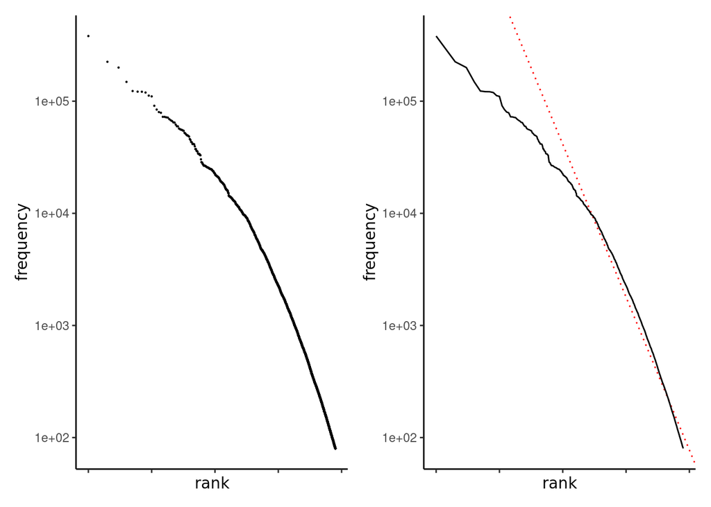

```r
head(freq, 10)
```

|  | feature | frequency | rank | docfreq | group |
| --- | --- | --- | --- | --- | --- |
| 1 | doge | 381198 | 1 | 293322 | all |
| 2 | buy | 224730 | 2 | 176649 | all |
| 3 | just | 199584 | 3 | 179977 | all |
| 4 | can | 148706 | 4 | 128251 | all |
| 5 | people | 123241 | 5 | 99611 | all |
| 6 | like | 121690 | 6 | 109053 | all |
| 7 | get | 121479 | 7 | 108771 | all |
| 8 | hold | 119472 | 8 | 91079 | all |
| 9 | now | 112162 | 9 | 103242 | all |
| 10 | dogecoin | 110414 | 10 | 84236 | all |

Guardando la frequenza delle parole nel testo, si può notare come ci sia una relazione proporzionale inversa tra la frequenza della parola e il suo rank nella tabella di contigenza, seguendo la ZipF Law (Thurner et al. 2015).

$$p_r = \alpha * 1/r$$
dove r è il rank assegnato ad ogni parola del testo. Per molti testi $\alpha$ è circa pari 1, come mostrato dalla ZipF’s Law. Andando a visualizzare il rango e la frequenza in scala logaritmica, la curva dovrebbe avere quindi coefficente angolare pari a 1.

Nella sezione riferita all’analisi delle frequenze andremo a rimuovere le stop words per vedere quali siano le parole significative del dataset con maggior influenza

```r
# frequency dfm clean - with stop words
freq <- dfm.frequency(post_clean_dfm, 8000)
```

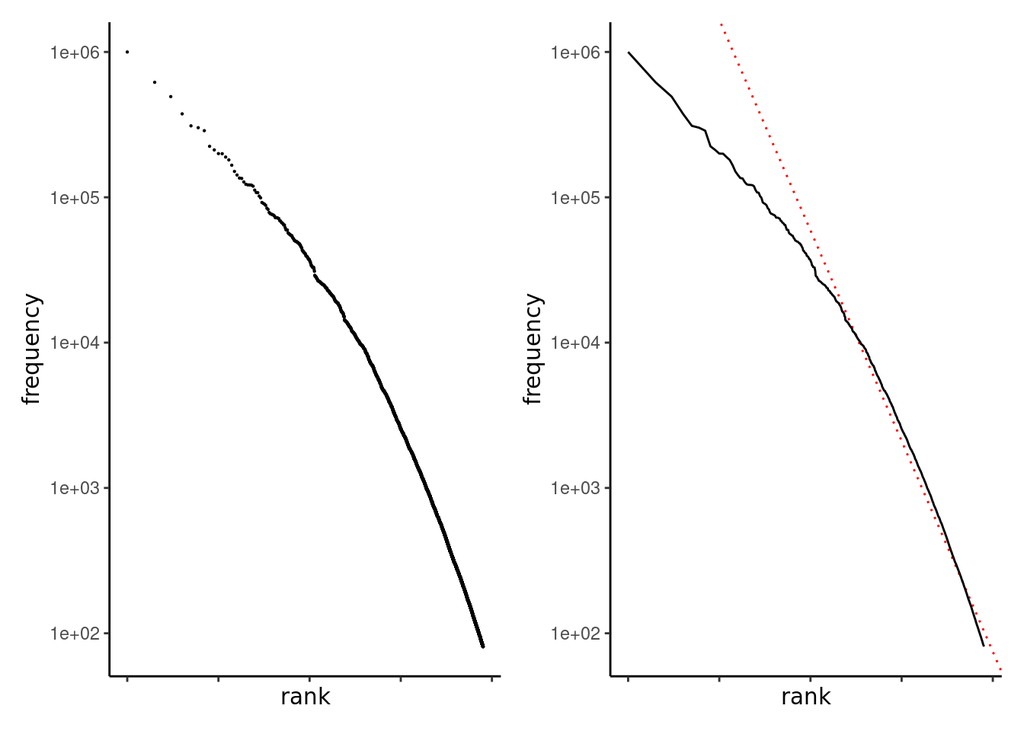

```r
head(freq, 10)
```

|  | feature | frequency | rank | docfreq | group |
| --- | --- | --- | --- | --- | --- |
| 1 | the | 999744 | 1 | 118583 | all |
| 2 | and | 618376 | 2 | 94160 | all |
| 3 | you | 493015 | 3 | 87288 | all |
| 4 | doge | 375144 | 4 | 76773 | all |
| 5 | for | 310196 | 5 | 74247 | all |
| 6 | this | 301169 | 6 | 74703 | all |
| 7 | that | 287359 | 7 | 75409 | all |
| 8 | buy | 224276 | 8 | 50605 | all |
| 9 | but | 211846 | 9 | 60353 | all |
| 10 | not | 199851 | 10 | 57793 | all |

Si può vedere come le parole con rank alti non rispecchiano quella che è la legge teorica, dove le frequenze sono meno di quelle previste. Questo perchè nei nostri testi abbiamo un’abbondanza di parole comuni superiore a parole considerate più rare, probabilmente dovute alla semplicità e brevità delle frasi che vengono scritte in un social media.

Proviamo ad utlizzare la statistica *tfidf* sul corpus dei post, per vedere se ci sia qualche differenza nelle parole considerate più frequenti.

```r
# compute tfidf
tfidf <- dfm_tfidf(post_clean_dfm)
topfeatures(tfidf)
```

```
##       the       and       you      doge       buy       for      this      that
## 187772.61 178077.87 158202.89 141292.22 125067.44 121337.58 117005.69 110466.53
##       but       not
## 101928.49  99919.08
```

##### And, with stemming?

Proviamo ad eseguire le medesime operazioni utilizzando però lo stemming, per raggruppare parole con la stessa radice.

Eseguiamo quindi la pulizia dei tokens utilizzando l’argomento *mode = ‘stem’* per eseguire lo stemming su di essi.

```r
com_clean_tidy_stem <- corpus.clean_tidy(com_doge_tidy, mode = "stem")

com_clean_dfm_stem <- com_clean_tidy_stem %>%
    cast_dfm(document, words, count)
# print(com_clean_dfm)

post_clean_tidy_stem <- corpus.clean_tidy(post_doge_tidy, mode = "stem")

post_clean_dfm_stem <- post_clean_tidy_stem %>%
    cast_dfm(document, words, count)
# print(post_clean_dfm)
```

```r
print_("CLEAN COMMENT CORPUS DIM (docsxtoks): ")
```

```
##
## CLEAN COMMENT CORPUS DIM (docsxtoks):
```

```r
print(dim(com_clean_dfm_stem))
```

```
## [1] 1850517  110844
```

```r
print_("CLEAN POST CORPUS DIM: (docsxtoks)")
```

```
##
## CLEAN POST CORPUS DIM: (docsxtoks)
```

```r
print(dim(post_clean_dfm_stem))
```

```
## [1] 182744 110847
```

```r
print_("COLS of TIDY DF")
```

```
##
## COLS of TIDY DF
```

```r
print(colnames(com_clean_tidy_stem))
```

```
## [1] "document" "count"    "words"
```

```r
print_("TYPE OF TIDY DF")
```

```
##
## TYPE OF TIDY DF
```

```r
print(typeof(com_clean_tidy_stem))
```

```
## [1] "list"
```

```r
# frequency dfm clean - with stemming
freq <- dfm.frequency(com_clean_dfm_stem, 8000)
```

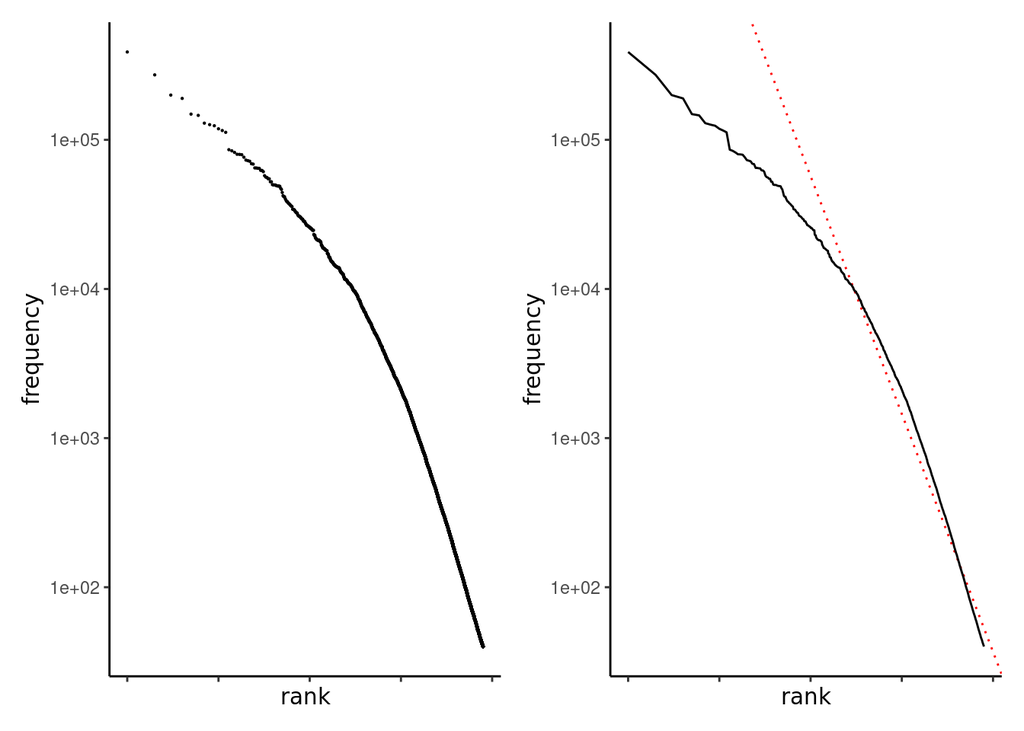

```r
head(freq, 10)
```

|  | feature | frequency | rank | docfreq | group |
| --- | --- | --- | --- | --- | --- |
| 1 | doge | 388273 | 1 | 300911 | all |
| 2 | buy | 272690 | 2 | 222014 | all |
| 3 | just | 199600 | 3 | 179993 | all |
| 4 | hold | 189566 | 4 | 158571 | all |
| 5 | can | 148764 | 5 | 128308 | all |
| 6 | get | 145894 | 6 | 132547 | all |
| 7 | like | 129387 | 7 | 116512 | all |
| 8 | sell | 126421 | 8 | 112121 | all |
| 9 | peopl | 124313 | 9 | 100659 | all |
| 10 | dogecoin | 118568 | 10 | 91889 | all |

```r
# frequency dfm clean - with stop words - stemming
freq <- dfm.frequency(post_clean_dfm_stem, 8000)
```

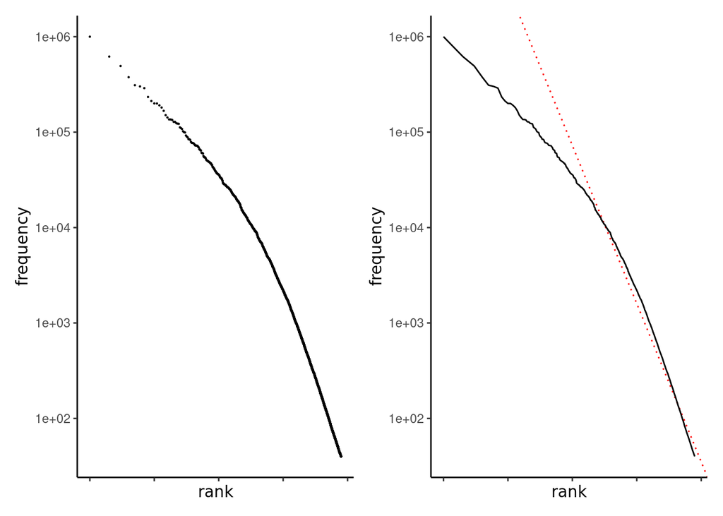

```r
head(freq, 10)
```

|  | feature | frequency | rank | docfreq | group |
| --- | --- | --- | --- | --- | --- |
| 1 | the | 999744 | 1 | 118583 | all |
| 2 | and | 618376 | 2 | 94160 | all |
| 3 | you | 493015 | 3 | 87288 | all |
| 4 | doge | 376289 | 4 | 77836 | all |
| 5 | for | 310196 | 5 | 74247 | all |
| 6 | this | 301169 | 6 | 74703 | all |
| 7 | that | 288911 | 7 | 76894 | all |
| 8 | buy | 233620 | 8 | 58534 | all |
| 9 | but | 211862 | 9 | 60369 | all |
| 10 | not | 199852 | 10 | 57794 | all |

```r
#
```

##### Tokenization of Bigrams

```r
if (save) {
    data <- readRDS("../Data/dogecoin.rds")

} else {
    if (!(exists("doge_com_raw_data"))) {
        doge_com_raw_data <- read.csv("../Data/src/dogecoin_com.csv")
    }

    # create and save data (df + corpus)
    data <- df.create(doge_com_raw_data, "Data", "dogecoin",
        filter_post = 0)
    remove(doge_com_raw_data)
}

post_corpus <- data$corpus_post
comm_corpus <- data$corpus_comm
remove(data)
```

```r
# !! PROBLEM FOR MEMORY
com_doge <- corpus.tokenize_dfmTidy(comm_corpus, ngrams = 2,
    dfm_b = FALSE)
remove(comm_corpus)

post_doge <- corpus.tokenize_dfmTidy(post_corpus, ngrams = 2,
    dfm_b = FALSE)

com_tidy <- com_doge$tidy
post_tidy <- post_doge$tidy

remove(com_doge)
remove(post_doge)
```

```r
com_clean_tidy <- corpus.clean_tidy(com_tidy, ngrams = 2)
remove(com_tidy)

print_("CLEAN COMMENT CORPUS: ")
```

```
##
## CLEAN COMMENT CORPUS:
```

```r
com_clean_bigram_dfm <- com_clean_tidy %>%
    cast_dfm(document, words, count)
print(com_clean_bigram_dfm)
```

```
## Document-feature matrix of: 1,574,131 documents, 3,200,150 features (>99.99% sparse) and 0 docvars.
##        features
## docs    decentralized communication communication networks networks millions
##   1                               1                      1                 1
##   612                             1                      0                 0
##   17564                           0                      0                 0
##   26959                           0                      0                 0
##   74468                           0                      0                 0
##   82496                           0                      0                 0
##        features
## docs    millions users users worldwide worldwide besides besides chat
##   1                  1               1                 1            1
##   612                0               0                 0            0
##   17564              1               0                 0            0
##   26959              1               0                 0            0
##   74468              1               0                 0            0
##   82496              1               0                 0            0
##        features
## docs    chat rooms rooms microblogging microblogging discussion
##   1              1                   1                        1
##   612            0                   0                        0
##   17564          0                   0                        0
##   26959          0                   0                        0
##   74468          0                   0                        0
##   82496          0                   0                        0
## [ reached max_ndoc ... 1,574,125 more documents, reached max_nfeat ... 3,200,140 more features ]
```

```r
remove(com_clean_tidy)
remove(com_clean_bigram_dfm)

post_clean_tidy <- corpus.clean_tidy(post_tidy, ngrams = 2)
remove(post_tidy)

print_("CLEAN POST CORPUS: ")
```

```
##
## CLEAN POST CORPUS:
```

```r
post_clean_bigram_dfm <- post_clean_tidy %>%
    cast_dfm(document, words, count)
print(post_clean_bigram_dfm)
```

```
## Document-feature matrix of: 173,105 documents, 3,663,943 features (>99.99% sparse) and 0 docvars.
##            features
## docs        get mine mine either halving happen happen many many coin
##   t3_ccjlvc        1           1              0           0         0
##   t3_eorhaf        1           0              0           0         0
##   t3_hczd2p        1           0              0           0         0
##   t3_kcd422        1           0              0           1         0
##   t3_kmn9bl        1           0              0           0         0
##   t3_kossxk        1           0              0           0         0
##            features
## docs        coin prices prices probably probably rise rise reasoning tell wait
##   t3_ccjlvc           0               0             0              0         0
##   t3_eorhaf           0               0             0              0         0
##   t3_hczd2p           0               0             0              0         0
##   t3_kcd422           0               0             0              0         0
##   t3_kmn9bl           0               0             0              0         0
##   t3_kossxk           0               0             0              0         0
## [ reached max_ndoc ... 173,099 more documents, reached max_nfeat ... 3,663,933 more features ]
```

###### Summary table

Si mostra la tabella di contingenza prima di aver applicato la correzione del dizionario:

[output not shown]

- with stop words ** tokens not unique

##### Analize uncorrect words

Essendo i corpus di testo recuperati da un social media, perciò dalle parole digitate non ci si aspetta la correttezza ortografica. Sono quindi state utilizzate le funzioni della libreria *hunspell*, che permette di verificare se una parola risulta corretta o meno, rispetto il loro dizionario , oppure di individuare una lista di suggerimenti per la correzione.

```r
if (save) {
    data <- readRDS("../Data/dogecoin.rds")
} else {
    doge_com_raw_data <- read.csv("../Data/src/dogecoin_com.csv")

    # create and save data (df + corpus)
    data <- df.create(doge_com_raw_data, "Data", "dogecoin",
        filter_post = 0)
    remove(doge_com_raw_data)
}

post_doge <- corpus.tokenize_dfmTidy(data$corpus_post, remove_stop = FALSE)
post_clean_tidy <- corpus.clean_tidy(post_doge$tidy, mode = "none")

remove(data)
remove(post_doge)
```

Ricaricati i dati in memoria, si va a conteggiare il numero di tokens riconosciuti come corretti o meno nel corpus riferito ai post.

```r
correct_post <- post_clean_tidy %>%
    distinct(words) %>%
    mutate(check = hunspell_check(words))

print(summary(correct_post$check))
```

```
##    Mode   FALSE    TRUE
## logical  105205   36129
```

```r
perc_f <- sum(correct_post$check == FALSE)/dim(correct_post)[1] *
    100
perc_t <- sum(correct_post$check == TRUE)/dim(correct_post)[1] *
    100

print_(paste0("UNCORRECT WORDS ", round(perc_f, 2), "% of total words",
    sep = " "))
```

```
##
## UNCORRECT WORDS 74.44% of total words
```

```r
print_(paste0("CORRECT WORDS ", round(perc_t, 2), "% of total words",
    sep = " "))
```

```
##
## CORRECT WORDS 25.56% of total words
```

Come si è potuto vedere dai precedenti risultati, il numero di parole classificate come lessicalmente non corrette risulta molto alto. Si è provato quindi a recuperare almeno le parole maggiormente influenti nel dataset.

```r
correct_post <- post_clean_tidy %>%
    mutate(check = hunspell_check(words))


print(summary(correct_post))
```

```
##    document             count             words             check
##  Length:10550292    Min.   :    1.00   Length:10550292    Mode :logical
##  Class :character   1st Qu.:    1.00   Class :character   FALSE:890823
##  Mode  :character   Median :    1.00   Mode  :character   TRUE :9659469
##                     Mean   :    2.14
##                     3rd Qu.:    1.00
##                     Max.   :39625.00
```

```r
remove(post_clean_tidy)
```

La seguente funzione, oltre ad aggregare i conteggi delle parole ripetute avendo un id del documento diverso, aggiunge al dataframe una colonna con valori booleani per indicare se la parola risulta corretta o meno. Da notare come molte parole non comuni, come per esempio ‘dogecoin,’ non vengono classificate come corrette.

```r
words.spell_checking <- function(data, word) {
    # counts word
    com_counts <- corpus.countPlot_tidy(data, bool_plot_count = FALSE,
        bool_plot_frequency = FALSE)
    # print(com_counts) check words
    com_correct <- com_counts %>%
        mutate.(check = hunspell_check({
            {
                word
            }
        }))

    print(paste0("RAW WORDS: ", dim(com_correct)[1], sep = " "))

    # aggregate for words
    correct_unique <- aggregate(count ~ {
        {
            word
        }
    } + check, data = com_correct, FUN = sum)

    # extract correct
    correct <- correct_unique %>%
        filter(check == TRUE)

    print_(paste0("CORRECTS WORDS: ", dim(correct)[1], "   ",
        round((dim(correct)[1]/dim(correct_unique)[1]) * 100,
            2), "%", sep = " "))

    # extract uncorrect
    uncorrect <- com_correct %>%
        filter(check == FALSE)

    print_(paste0("UNCORRECTS WORDS: ", dim(uncorrect)[1], "   ",
        round(dim(uncorrect)[1]/dim(correct_unique)[1] * 100,
            2), "%", sep = " "))

    return(list(correct = correct, uncorrect = uncorrect))
}
```

La precedente funzione potrà esser utilizzata anche per analizzare gli altri dataset raccolti.

```r
# spell checking add counts and freq.
df <- words.spell_checking(correct_post)
```

```
## [1] "RAW WORDS: 141334 "
##
## CORRECTS WORDS: 36129   25.56%
##
## UNCORRECTS WORDS: 105205   74.44%
```

```r
correct_post <- df$correct
uncorrect_post <- df$uncorrect

remove(df)
remove(correct_post)
```

Una volta estratte le parole riconosciute come corrette e divise da quelle non corrette possiamo procedere all’analisi e correzione. Per iniziare, andiamo a calcolare per ciascuna parola la sua lemmatizzazione e lo stemming, che potranno esser utili per calcolare le distanze tra stringhe e prendere una decisione sulla correzione da effettuare.

```r
uncorrect_stem_lem <- uncorrect_post %>%
    cbind(term_stem = uncorrect_post$words) %>%
    cbind(term_lem = uncorrect_post$words) %>%
    word.manipulation(term_stem, mode = 2) %>%
    word.manipulation(term_lem, mode = 1) %>%
    rename(term = words)

dim(uncorrect_stem_lem)
```

```
## [1] 105205      7
```

```r
summary(uncorrect_stem_lem)
```

```
##      term               count           total_of_word        frequency
##  Length:105205      Min.   :     1.00   Min.   :22615470   Min.   :4.400e-08
##  Class :character   1st Qu.:     1.00   1st Qu.:22615470   1st Qu.:4.400e-08
##  Mode  :character   Median :     1.00   Median :22615470   Median :4.400e-08
##                     Mean   :    14.09   Mean   :22615470   Mean   :6.230e-07
##                     3rd Qu.:     2.00   3rd Qu.:22615470   3rd Qu.:8.800e-08
##                     Max.   :111786.00   Max.   :22615470   Max.   :4.943e-03
##    check          term_stem           term_lem
##  Mode :logical   Length:105205      Length:105205
##  FALSE:105205    Class :character   Class :character
##                  Mode  :character   Mode  :character
##
##
##
```

Sempre a causa degli errori grammaticali, certe parole, ma sopratutto certe stopwords, non vengono riconosciute e i suggerimenti per la correzione risultano a loro volta sbagliati. Di seguito una prima funzione per effettuare una correzione manuale della parola, altrimenti si chiama la funzione *hunspell_suggest* da cui viene preso il primo elemento suggerito.

Eseguiamo questa funzione all’interno di una pipe di *dplyr*, per poi aggiungere al dataset le distanze tra le diverse stringhe nella lista.

```r
words.spell_checking <- function(data, input) {
   data %>%
      mutate( suggest =
             case_when(
               # any manual corrections
               {{input}} == 'gbp' ~ 'gbp',
               {{input}} == 'halving' ~ 'halving',
               {{input}} == 'aways' ~ 'away',
               {{input}} == 'covid' ~ 'covid',
               {{input}} == 'binance' ~ 'binance',
               {{input}} == 'stonks' ~ 'stonks',
               {{input}} == 'cryptocurrency' ~ 'cryptocurrency',
               {{input}} == 'cryptocurrencies' ~ 'cryptocurrency',

               {{input}} == "didn" ~ "did not",
               {{input}} == "doesn" ~ "does not",
               {{input}} == "aren" ~ "are not",
               {{input}} == "isn" ~ "is not",
               {{input}} == "isnt" ~ "is not",
               {{input}} == "wasn" ~ "was not",
               {{input}} == "weren" ~ "were not",
               {{input}} == "couldn" ~ "could not",
               {{input}} == "wasnt" ~ "was not",
               {{input}} == "wouldn" ~ "would not",
               {{input}} == "wouldnt" ~ "would not",
               {{input}} == 'hadn' ~ 'had not',

               {{input}} == "ive" ~ "i have",
               {{input}} == "youre" ~ "you are",

               # check and (if required) correct spelling
               !hunspell_check({{input}}) ~
                  hunspell_suggest({{input}}) %>%
                  # get first suggestion, or NA if suggestions list is empty
                  map(1, .default = NA) %>%
                  unlist() %>%
                  tolower(),
               TRUE ~ {{input}} # if word is correct
            ))
            # if input incorrectly spelled but no suggestions, return input word
           # ifelse(is.na(output), {{input}}, output)
}

# apply suggest
suggest_stem_corFalse <- uncorrect_stem_lem %>%
   words.spell_checking(term) %>%
   mutate(dist_term = stringdist::stringdist(term, suggest, "lv")) %>%
   mutate(dist_stem = stringdist::stringdist(term_stem, suggest, "lv")) %>%
   mutate(dist_source_stem = stringdist::stringdist(term, term_stem, "lv")) %>%
   mutate(dist_lem = stringdist::stringdist(term_lem, suggest, "lv")) %>%
   select(count, term, suggest, term_stem, term_lem, dist_term, dist_source_stem)


if(save){ write_rds(suggest_stem_corFalse, "../Data/doge_suggest.rds") }

remove(uncorrect_stem_lem)
remove(uncorrect_post)
```

Siamo andati a calcolare la *distanza di levenshtein* tra la parola data, il suggerimento e lo stemming della parola inziale, questo per poter scegliere in base ad essa se utilizzare il suggerimento o lo stemming del termine.

Possiamo adesso effettuare una correzione più precisa delle parole che presentano delle frequenze nel testo abbastanza alte, tali da esser influenti nell’analisi. Nel seguente codice ci riferiremo con ‘*large dictionary*’ al dizionario che contiene le parole con i conteggi più alti e con ‘*medium*’ la fascia mediana, i loro nomi non rispecchiano quindi le dimensioni del dataset.

```r
if (save) {
    dic_suggest = readRDS("../Data/doge_suggest.rds")
} else {
    dic_suggest = suggest_stem_corFalse
}
remove(suggest_stem_corFalse)


# ????????  holddddd holddddd buyyyy buyyyy
word.little_correction <- function(input) {
    output <- case_when(input == "hodl" ~ "hold", input == "obis" ~
        "boys", input == "fuckin" ~ "fucking", input == "ios" ~
        "ios", input == "gpu" ~ "gpu", input == "gme" ~ "gme",
        input == "font" ~ "dont", input == "stonks" ~ "stonks",
        grepl("^hold[d+]", input) ~ "hold", grepl("^s[o+]", input) ~
            "so", grepl("^g[o+]", input) ~ "go", grepl("^usa",
            input) ~ "usa", TRUE ~ input)
    ifelse(is.na(output), input, output)
}


## stop words from snowball
stopwords <- get_stopwords(language = "en", source = "snowball")
stopwords_ <- as.vector(stopwords$word)
remove(stopwords)

# augmented stopwords take words whit '
other <- purrr::keep(stopwords_, function(x) grepl("['-]+", x))
other1 <- gsub("[[:punct:]]", "", other)
other2 <- unique(gsub("[[:punct:]][a-z]+", "", other))
ohter3 <- c("didn", "doesn", "aren", "isn", "wasn", "weren",
    "couldn", "hadn")

stopwords <- c(stopwords_, other1, other2)
remove(other, other1, other2)

dim <- dim(dic_suggest)[1]
```

La correzione è stata effettuata con i seguenti passi: - assegnare a una variabile colonna *flag* un valore binario per indicare se la parola è presente tra le stopwords o meno. - Se la parola è una stopwords viene utilizzato il suggerimento ritornato da *hunspell*, altrimenti viene impostata come correzione lo stemming della parola.

Dopo aver corretto le stopwords, si procede come segue: - Se la distanza tra la stringa di partenza e il suo stemming è pari a 0, allora la parola non viene corretta non essendoci una radice riconoscible come stemming. - Se la distanza sopra è maggiore di zero e la distanza tra la parola iniziale e il suggerimento di correzione è pari a zero, viene utilizzata come correzione il suggerimento dato da *hunspell*

```r
# dic with influence uncorret words
dic_l.tdb <- tidytable(dic_suggest) %>%
    filter(count >= 500) %>%
    cbind(flag = -1) %>%
    cbind(correction = "none") %>%
    select.(count, term, term_stem, term_lem, suggest, flag,
        correction, dist_source_stem, dist_term)

# flag if a word is in stopwords vec
dic_l.tdb$flag = ifelse.(dic_l.tdb$term_stem %in% stopwords,
    1, 0)

# if is a stopwords, use suggested words
dic_l.tdb$correction = ifelse.(dic_l.tdb$flag == 1, dic_l.tdb$suggest,
    dic_l.tdb$term_stem)

# if lev dist from raw string and stem. string is 0 ..
dic_l.tdb$correction = ifelse.(dic_l.tdb$dist_source_stem ==
    0 & dic_l.tdb$flag != 1, dic_l.tdb$term, dic_l.tdb$correction)

dic_l.tdb$correction = ifelse.(dic_l.tdb$dist_source_stem !=
    0 & dic_l.tdb$dist_term == 0 & dic_l.tdb$flag != 1 & dic_l.tdb$dist_term <
    dic_l.tdb$dist_source_stem, dic_l.tdb$suggest, dic_l.tdb$correction)


dic_l.tdb %>%
    filter(flag == 1)
```

| count | term | term_stem | term_lem | suggest | flag | correction | dist_source_stem | dist_term |
| --- | --- | --- | --- | --- | --- | --- | --- | --- |
| 6990 | aren | aren | aren | are not | 1 | are not | 0 | 3 |
| 723 | arent | arent | arent | rent | 1 | rent | 0 | 1 |
| 4166 | couldn | couldn | couldn | could not | 1 | could not | 0 | 3 |
| 19116 | didn | didn | didn | did not | 1 | did not | 0 | 3 |
| 2560 | didnt | didnt | didnt | dint | 1 | dint | 0 | 1 |
| 21961 | doesn | doesn | doesn | does not | 1 | does not | 0 | 3 |
| 2374 | doesnt | doesnt | doesnt | doesn't | 1 | doesn't | 0 | 1 |
| 20889 | dont | dont | do | font | 1 | font | 0 | 1 |
| 3093 | hasn | hasn | hasn | has | 1 | has | 0 | 1 |
| 661 | havent | havent | havent | haven | 1 | haven | 0 | 1 |

[output cut: 12 more lines]

```r
print("stop words founded")
```

```
## [1] "stop words founded"
```

```r
print(sum(dic_l.tdb$flag))
```

```
## [1] 22
```

```r
print("nrow large dictionary")
```

```
## [1] "nrow large dictionary"
```

```r
print(nrow(dic_l.tdb))
```

```
## [1] 277
```

```r
print("in %")
```

```
## [1] "in %"
```

```r
print(sum(dic_l.tdb$flag)/nrow(dic_l.tdb) * 100)
```

```
## [1] 7.942238
```

```r
dic_l <- dic_l.tdb %>%
    mutate.(correction = word.little_correction(correction)) %>%
    select.(count, term, correction, flag) %>%
    mutate.(check = hunspell_check(correction)) %>%
    group_by(flag) %>%
    arrange.(desc(count))

print_("Number of words in my large dictionary")
```

```
##
## Number of words in my large dictionary
```

```r
print(nrow(dic_l))
```

```
## [1] 277
```

Si eseguono le medesime operazioni con le parole che hanno una frequenza compresa tra 100 e 500 esclusi. Ci si aspetta di trovare un minor numero di stop words, ma l’obiettivo è tentare di correggere il termine se possibile, se no stemmizzare la parola.

Un problema che non è stato risolto con questa correzione è quello dovuto a caratteri battuti come doppi all’interno delle parole, o comunque risolvere le occorrenze strane all’interno delle parole. Queste verranno escluse dall’analisi del testo, ma non potranno esser utilizzate nei conteggi delle parole, risultando inutili a livello di informazione che portano.

```r
# merge with dic of true word
dic_m.tdb <- tidytable(dic_suggest) %>%
    filter.(count > 100 & count < 500) %>%
    cbind(flag = -1) %>%
    cbind(correction = "none") %>%
    select.(count, term, term_stem, term_lem, suggest, flag,
        correction, dist_source_stem)

# flag if a word is in stopwords vec
dic_m.tdb$flag = ifelse.(dic_m.tdb$term_stem %in% stopwords,
    1, 0)

# if is a stopwords, use suggested words
dic_m.tdb$correction = ifelse.(dic_m.tdb$flag == 1, dic_m.tdb$suggest,
    dic_m.tdb$term_stem)

# if lev dist from raw string and stem. string is 0 ..
dic_m.tdb$correction = ifelse.(dic_m.tdb$dist_source_stem ==
    0 & dic_m.tdb$flag != 1, dic_m.tdb$term, dic_m.tdb$suggest)
print("stop words founded")
```

```
## [1] "stop words founded"
```

```r
print(sum(dic_m.tdb$flag))
```

```
## [1] 10
```

```r
print("nrow medium dictionary")
```

```
## [1] "nrow medium dictionary"
```

```r
print(nrow(dic_m.tdb))
```

```
## [1] 789
```

```r
print("in %")
```

```
## [1] "in %"
```

```r
print(sum(dic_m.tdb$flag)/nrow(dic_m.tdb) * 100)
```

```
## [1] 1.267427
```

```r
dic_m <- dic_m.tdb %>%
    mutate(correction = word.little_correction(correction)) %>%
    select(count, term, correction, flag) %>%
    mutate.(check = hunspell_check(correction)) %>%
    group_by(flag) %>%
    arrange(desc(count))

head(dic_m, 10)
```

| count | term | correction | flag | check |
| --- | --- | --- | --- | --- |
| 499 | cpu | cpu | 0 | FALSE |
| 499 | ffs | ffs | 0 | FALSE |
| 498 | dogo | dogo | 0 | FALSE |
| 496 | underdoge | underdog | 0 | TRUE |
| 493 | bhttps | bhttps | 0 | FALSE |
| 493 | gbp | gbp | 0 | FALSE |
| 493 | myreminders | my reminders | 0 | FALSE |
| 491 | biden | biden | 0 | FALSE |
| 488 | july | july | 0 | FALSE |
| 486 | asic | asic | 0 | FALSE |

```r
dictionary = bind_rows(dic_l %>%
    select.(term, correction), dic_m %>%
    select.(term, correction))

if (save) {
    write_rds(dictionary, "../Data/dictionary.rds")
}
```

```r
remove(dic_l)
remove(dic_m)
remove(dic_m.tdb)
remove(dic_l.tdb)
remove(dic_suggest)
```

### Remake Corpus

Durante la correzione del testo abbiamo recuperato alcune parole digitate male e nel caso non ci fosse una correzione abbiamo applicato lo stemming

```r
if (save) {
    dict <- readRDS("../Data/dictionary.rds")
} else {
    dict = dictionary
}
remove(dictionary)

dict <- dict %>%
    drop_na()
dic_words <- dict$term
correct <- dict$correction

toks <- quanteda::tokens(dict$term)
head(toks, 5)
```

```
## Tokens consisting of 5 documents.
## text1 :
## [1] "dogecoin"
##
## text2 :
## [1] "crypto"
##
## text3 :
## [1] "robinhood"
##
## text4 :
## [1] "binance"
##
## text5 :
## [1] "hodl"
```

```r
# test replace words
toks2 <- tokens_replace(toks, dic_words, correct, valuetype = "fixed",
    case_insensitive = TRUE)

head(toks2, 5)
```

```
## Tokens consisting of 5 documents.
## text1 :
## [1] "dogecoin"
##
## text2 :
## [1] "crypto"
##
## text3 :
## [1] "robinhood"
##
## text4 :
## [1] "binance"
##
## text5 :
## [1] "hold"
```

Uniamo questa logica alla funzione *corpus.tokenize_dfmTidy* che abbiamo definito precedentemente, in tal modo tramite argomento potremmo scegliere se utilizzare la sostituzione delle parole o meno.

Possiamo così creare il nostro nuovo corpus, sostituendo tutte le parole presenti nel nostro dizionario con la loro correzione.

Si potrebbe correggere tutte le parole restanti (quelle con conteggi minori) utilizzando la lemmatizzazione.

```r
if (save) {
    data <- readRDS("../Data/dogecoin.rds")
}

post_doge_correct <- corpus.tokenize_dfmTidy(data$corpus_post,
    remove_stop = FALSE, spell_checking = TRUE, mode_correction = 0)

# if(save){write_rds(post_doge_correct,
# '../Data/post_doge_raw_myCorrection.rds')}
```

[figure not shown]

[output not shown]

[output cut: 40 more lines]

```r
# if(save){ remove(post_doge_correct) post_doge_correct <-
# readRDS('../Data/post_doge_raw_myCorrection.rds') }

tidy_doge_correct <- post_doge_correct$tidy
dfm_doge_correct <- post_doge_correct$dfm
remove(post_doge_correct)

dfm.frequency(dfm_doge_correct)
```

```r
remove(dfm_doge_correct)
```

Abbiamo però alcuni tokens che dopo la manipolazione comprendono due termini, dobbiamo quindi separarli ed andare nuovamente ad aggregare i conteggi.

```r
# cast to tidytable
tidy_doge_correct <- tidytable(tidy_doge_correct)
# split words
post_doge_correct_tidy <- tidy_doge_correct %>%
    mutate.(term = strsplit(term, " ")) %>%
    unnest.(term)
```

```r
# verify it
post_doge_correct_tidy %>%
    filter(term == "did not")
```

| document | count | term |
| --- | --- | --- |

```r
dfm_correct_doge <- post_doge_correct_tidy %>%
    cast_dfm(document, term, count)


if (save) {
    write_rds(dfm_correct_doge, "../Data/post_doge_myCorrection.rds")
}

remove(tidy_doge_correct)
remove(post_doge_correct_tidy)
```

### Overview of semi-clean Doge Dataset

Ripetiamo l’analisi del dataset con i token corretti per confrontarne i conteggi.

```r
# create tokens with correction and stop words --> for
# sentiment create tokens with correction and without stop
# words --> for counts

if (save) {
    remove(dfm_correct_doge)
    data <- readRDS("../Data/post_doge_myCorrection.rds")
} else {
    data = dfm_correct_doge
}

# cast to tidy
data_tidy <- tidytext::tidy(data)
```

```r
print("REDDIT's POST CORPUS with correction: ")
```

```
## [1] "REDDIT's POST CORPUS with correction: "
```

```r
print(summary(data_tidy))
```

```
##    document             term               count
##  Length:12420209    Length:12420209    Min.   :    1.00
##  Class :character   Class :character   1st Qu.:    1.00
##  Mode  :character   Mode  :character   Median :    1.00
##                                        Mean   :    2.41
##                                        3rd Qu.:    2.00
##                                        Max.   :40028.00
```

```r
# clean tokens
post_clean_tidy <- corpus.clean_tidy(data_tidy, mode = "none")

# print('CLEAN POST CORPUS: ')
post_clean_dfm <- post_clean_tidy %>%
    cast_dfm(document, words, count)
# print(post_clean_dfm)


print_("CLEAN POST CORPUS DIM: (docsxtoks)")
```

```
##
## CLEAN POST CORPUS DIM: (docsxtoks)
```

```r
print(dim(post_clean_dfm))
```

```
## [1] 182736 141269
```

```r
print("COLS of TIDY DF")
```

```
## [1] "COLS of TIDY DF"
```

```r
print(colnames(post_clean_tidy))
```

```
## [1] "document" "count"    "words"
```

```r
print("TYPE OF TIDY DF")
```

```
## [1] "TYPE OF TIDY DF"
```

```r
print(typeof(post_clean_tidy))
```

```
## [1] "list"
```

Analizziamo nuovamente il numero di parole corrette e tra quelle scorrette quali sono quelle con i conteggi maggiori.

```
df <- words.spell_checking(post_clean_tidy, post_clean_tidy$words)

df$uncorrect %>%
   arrange(desc(count))
```

```
remove(df)
```

Si va quindi a vedere se il grafico delle frequenze abbia subito qualche cambiamento.

```r
# frequency dfm clean - with stop words
freq <- dfm.frequency(post_clean_dfm, 8000)
```

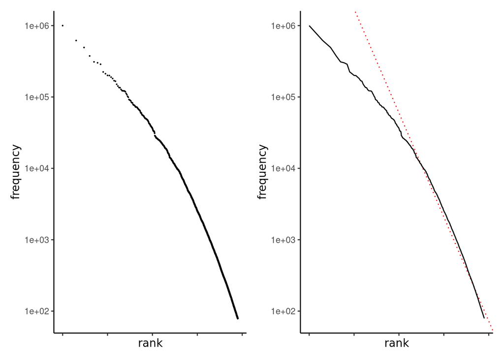

```r
head(freq, 10)
```

|  | feature | frequency | rank | docfreq | group |
| --- | --- | --- | --- | --- | --- |
| 1 | the | 999744 | 1 | 118583 | all |
| 2 | and | 618376 | 2 | 94160 | all |
| 3 | you | 493178 | 3 | 87444 | all |
| 4 | doge | 375680 | 4 | 76899 | all |
| 5 | for | 310217 | 5 | 74268 | all |
| 6 | this | 301169 | 6 | 74703 | all |
| 7 | that | 287359 | 7 | 75409 | all |
| 8 | buy | 224276 | 8 | 50605 | all |
| 9 | but | 211846 | 9 | 60353 | all |
| 10 | not | 200445 | 10 | 58374 | all |

Anche in questo caso il grafico non ha avuto importanti cambiamenti. A differenza del grafico visualizzato prima di dividere i tokens che presentava una curva più in linea con la legge di ZipF, avendo separato molte stopwords sono aumentate le parole comuni.

Si potrebbe valutare di utilizzare un correttore su tutti i token presenti, ma sarebbe necessario verificare che la correzzioni sia valida e non cambi completamente il significato della parola.

```r
remove(post_clean_dfm)
remove(post_clean_tidy)
remove(dfm_correct_doge)
remove(freq)
```

Per completezza andiamo ad analizzare i conteggi anche per i bigrammi creati a partire dai dati con alcune parole corrette.

```r
if (save) {
    data <- readRDS("../Data/dogecoin.rds")
}
post_corpus <- data$corpus_post
remove(data)

post_doge <- corpus.tokenize_dfmTidy(post_corpus, remove_stop = FALSE,
    spell_checking = TRUE, mode_correction = 0, ngrams = 2)
print("REDDIT's POST CORPUS: ")
print(post_doge$dfm)

remove(post_corpus)
```

```r
post_clean_tidy <- post_doge$tidy
remove(post_doge)
post_clean_tidy <- corpus.clean_tidy(post_clean_tidy, ngrams = 2)

print("CLEAN POST CORPUS: ")
post_clean_bigram_dfm <- post_clean_tidy %>%
    cast_dfm(document, words, count)
print(post_clean_bigram_dfm)
```

[output not shown]

- with spell checker ** tokens not unique

```
remove(post_clean_bigram_dfm)
remove(post_clean_tidy)
```